# Titanic Data Set: Exploratory Data Analysis

Starting point: [Make School Tutorial](https://makeschool.org/mediabook/oa/tutorials/titanic-dataset-tutorial-an-intro-to-data-analysis-and-statistics-n40/)

Data set: [Titanic - Machine Learning from Disaster](https://www.kaggle.com/c/titanic/data)

#### Notes:

- I used the tutorial from Make School as a starting point and expanded from there.
- I renamed the "train.csv" file to "titanic.csv" for simplicity and is found in the "data" directory. (Relative file path: "data/titanic.csv")
- This analysis requires the following packages:
  - `numpy`
  - `pandas`
  - `matplotlib`
  - `seaborn`

```python
import numpy as np
import pandas as pd
import matplotlib.pyplot as plt
import seaborn as sns
```

# Looking at the Data

```python
df = pd.read_csv("data/titanic.csv")

df.info()
df.head()
```

```
<class 'pandas.core.frame.DataFrame'>
RangeIndex: 891 entries, 0 to 890
Data columns (total 12 columns):
 #   Column       Non-Null Count  Dtype
---  ------       --------------  -----
 0   PassengerId  891 non-null    int64
 1   Survived     891 non-null    int64
 2   Pclass       891 non-null    int64
 3   Name         891 non-null    object
 4   Sex          891 non-null    object
 5   Age          714 non-null    float64
 6   SibSp        891 non-null    int64
 7   Parch        891 non-null    int64
 8   Ticket       891 non-null    object
 9   Fare         891 non-null    float64
 10  Cabin        204 non-null    object
 11  Embarked     889 non-null    object
dtypes: float64(2), int64(5), object(5)
memory usage: 83.7+ KB
```

|  | PassengerId | Survived | Pclass | Name | Sex | Age | SibSp | Parch | Ticket | Fare | Cabin | Embarked |
| --- | --- | --- | --- | --- | --- | --- | --- | --- | --- | --- | --- | --- |
| 0 | 1 | 0 | 3 | Braund, Mr. Owen Harris | male | 22.0 | 1 | 0 | A/5 21171 | 7.2500 | NaN | S |
| 1 | 2 | 1 | 1 | Cumings, Mrs. John Bradley (Florence Briggs Th... | female | 38.0 | 1 | 0 | PC 17599 | 71.2833 | C85 | C |
| 2 | 3 | 1 | 3 | Heikkinen, Miss. Laina | female | 26.0 | 0 | 0 | STON/O2. 3101282 | 7.9250 | NaN | S |
| 3 | 4 | 1 | 1 | Futrelle, Mrs. Jacques Heath (Lily May Peel) | female | 35.0 | 1 | 0 | 113803 | 53.1000 | C123 | S |
| 4 | 5 | 0 | 3 | Allen, Mr. William Henry | male | 35.0 | 0 | 0 | 373450 | 8.0500 | NaN | S |

## Features (that need explanation)

| Feature | Definition | Key |
| --- | --- | --- |
| Survived | survival | 0 = no; 1 = yes |
| Pclass | Ticket Class | 1 = 1st; 2 = 2nd; 3 = 3rd |
| SibSp | # of sbilings/spouses aboard | int |
| Parch¹ | # of parents / children aboard | int |
| Embarked | Port of Embarkment | C = Cherbourg; Q = Queenstown; S = Southampton |

***Notes***:  
¹ Some children travelled only with a nanny, therefore $parch = 0$ for them.  
² Age is a fraction if less than 1

#### Remove unnecessary features

Because I am just looking at the data, some of the features are not necessarily needed.

```python
df = df.drop(columns=["PassengerId"])    # Same as index
```

```
array([[<Axes: title={'center': 'Survived'}>,
        <Axes: title={'center': 'Pclass'}>],
       [<Axes: title={'center': 'Age'}>,
        <Axes: title={'center': 'SibSp'}>],
       [<Axes: title={'center': 'Parch'}>,
        <Axes: title={'center': 'Fare'}>]], dtype=object)
```

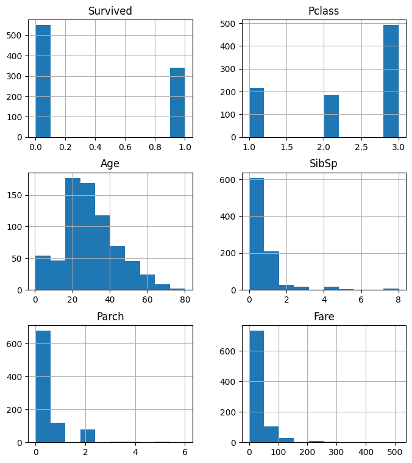

```python
# Distribution of quantitative features across all instances
df.hist(figsize=(8,9))
```

```python
# Features that I want to see the percentage distribution of
to_explore = ['Survived', 'Pclass', 'Sex', 'Embarked']
for feat in to_explore:
	display(df[feat].value_counts(normalize=True))
```

```
0    0.616162
1    0.383838
Name: Survived, dtype: float64
```

```
3    0.551066
1    0.242424
2    0.206510
Name: Pclass, dtype: float64
```

```
male      0.647587
female    0.352413
Name: Sex, dtype: float64
```

```
S    0.724409
C    0.188976
Q    0.086614
Name: Embarked, dtype: float64
```

## Observations

- 61 percent of passengers did not survive the voyage.
- 55 percent of passengers were in 3rd class.
- 65 percent of passengers were male.
- 72 percent of boarded in Southampton

# Variance

```python
# See the the central tendency, dispersion and shape of a dataset's distribution
df.describe()
```

|  | Survived | Pclass | Age | SibSp | Parch | Fare |
| --- | --- | --- | --- | --- | --- | --- |
| count | 891.000000 | 891.000000 | 714.000000 | 891.000000 | 891.000000 | 891.000000 |
| mean | 0.383838 | 2.308642 | 29.699118 | 0.523008 | 0.381594 | 32.204208 |
| std | 0.486592 | 0.836071 | 14.526497 | 1.102743 | 0.806057 | 49.693429 |
| min | 0.000000 | 1.000000 | 0.420000 | 0.000000 | 0.000000 | 0.000000 |
| 25% | 0.000000 | 2.000000 | 20.125000 | 0.000000 | 0.000000 | 7.910400 |
| 50% | 0.000000 | 3.000000 | 28.000000 | 0.000000 | 0.000000 | 14.454200 |
| 75% | 1.000000 | 3.000000 | 38.000000 | 1.000000 | 0.000000 | 31.000000 |
| max | 1.000000 | 3.000000 | 80.000000 | 8.000000 | 6.000000 | 512.329200 |

```python
# Calculate the variance of each feature
df.var()
```

```
Survived       0.236772
Pclass         0.699015
Age          211.019125
SibSp          1.216043
Parch          0.649728
Fare        2469.436846
dtype: float64
```

**Note**: High variance in the "Age" and "Fare" features.

## Looking at "Age" and "Fare" Closer

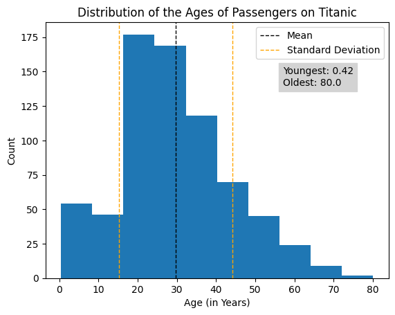

```python
# Age Histogram
plt.hist(df['Age'])
plt.axvline(df['Age'].mean(), color='k', linestyle='dashed', linewidth=1, label="Mean")
plt.title('Distribution of the Ages of Passengers on Titanic')
plt.ylabel('Count')
plt.xlabel('Age (in Years)')
plt.axvline(df['Age'].mean() + df['Age'].std(), color='orange', linestyle='dashed', linewidth=1, label="Standard Deviation")
plt.axvline(df['Age'].mean() - df['Age'].std(), color='orange', linestyle='dashed', linewidth=1)
plt.text(57,140, f"Youngest: {df['Age'].min()}\n" \
		 f"Oldest: {df['Age'].max()}",
		 backgroundcolor="lightgray")
plt.legend()
plt.show()
```

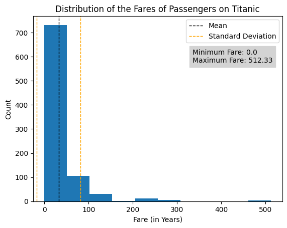

```python
# Fare Histogram
plt.hist(df['Fare'])
plt.axvline(df['Fare'].mean(), color='k', linestyle='dashed', linewidth=1, label="Mean")
plt.title('Distribution of the Fares of Passengers on Titanic')
plt.ylabel('Count')
plt.xlabel('Fare (in Years)')
plt.axvline(df['Fare'].mean() + df['Fare'].std(), color='orange', linestyle='dashed', linewidth=1, label="Standard Deviation")
plt.axvline(df['Fare'].mean() - df['Fare'].std(), color='orange', linestyle='dashed', linewidth=1)
plt.text(335, 575, f"Minimum Fare: {df['Fare'].min()}\n" \
		 f"Maximum Fare: {df['Fare'].max():.2f}",
		 backgroundcolor="lightgray")
plt.legend()
plt.show()
```

### Conclusion

Here, we can see that fares had a much larger variance than ages. This is also limited by the fact that a passenger can pay $500, but not live to be 500 years old.

# Correlations

```python
# Compute pairwise correlation of features
df.corr()
```

|  | Survived | Pclass | Age | SibSp | Parch | Fare |
| --- | --- | --- | --- | --- | --- | --- |
| Survived | 1.000000 | -0.338481 | -0.077221 | -0.035322 | 0.081629 | 0.257307 |
| Pclass | -0.338481 | 1.000000 | -0.369226 | 0.083081 | 0.018443 | -0.549500 |
| Age | -0.077221 | -0.369226 | 1.000000 | -0.308247 | -0.189119 | 0.096067 |
| SibSp | -0.035322 | 0.083081 | -0.308247 | 1.000000 | 0.414838 | 0.159651 |
| Parch | 0.081629 | 0.018443 | -0.189119 | 0.414838 | 1.000000 | 0.216225 |
| Fare | 0.257307 | -0.549500 | 0.096067 | 0.159651 | 0.216225 | 1.000000 |

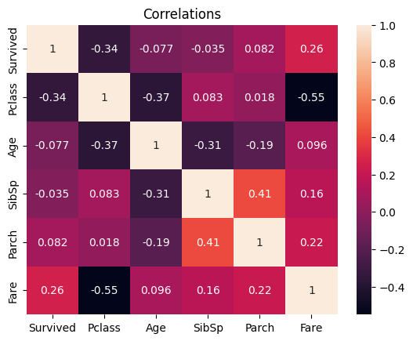

```python
# Plot correlation in a color-encoded matrix
sns.heatmap(df.corr(), annot=True)
plt.title("Correlations")
plt.show()
```

### Notes:

- Highest positive correlation between `sibsp` and `parch`
  - This makes sense because families often travel together
- Lowest negative correlation between `Pclass` and `Fare`
  - This also makes sense because lower class (e.g. 3rd class) tickets are usually cheaper than higher class (e.g. 1st class) tickets.
- `Age` and `Pclass` also have a moderately negatively correlated.
  - Possibly because richer people tend to be older.

## Considering Biological Sex

```python
sex = {"male": 1, "female": 0}
df["Sex"] = df["Sex"].map(sex)
```

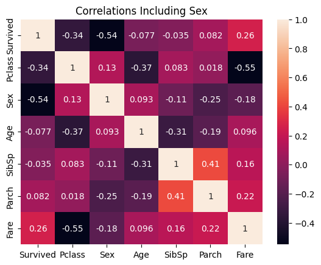

```python
sns.heatmap(df.corr(), annot=True)
plt.title("Correlations Including Sex")
plt.show()
```

**Note**: There is a strong correlation between `Sex` and `Survival`!

# Probabilistic Analysis

Which features influenced survival the most?

## "Women and Children First" Hypothesis

We found a correlation between `Sex` and `Survival`, but not between `Age` and `Survival`.

```python
# Women and children
w_c = df[(df['Sex'] == 0) | (df['Age'] < 16)]

# Survival Rate
# Normalize to get percentage over relative frequency
w_c_sr = w_c["Survived"].value_counts(normalize=True)
print("Survival Rate for Women and Children")
display(w_c_sr)

# Adult men
a_m = df[(df['Sex'] == 1) & (df['Age'] > 16)]

# Survival Rate
a_m_sr = a_m["Survived"].value_counts(normalize=True)
print("Survival Rate for Men")
display(a_m_sr)
```

```
Survival Rate for Women and Children
```

```
1    0.717514
0    0.282486
Name: Survived, dtype: float64
```

```
Survival Rate for Men
```

```
0    0.823383
1    0.176617
Name: Survived, dtype: float64
```

#### Observation

It seems that women and children were about 4x more likely to survive than adult men.

### Child Survival Rate

```python
children = df[df["Age"] < 16]
children.describe()
```

|  | Survived | Pclass | Sex | Age | SibSp | Parch | Fare |
| --- | --- | --- | --- | --- | --- | --- | --- |
| count | 83.000000 | 83.000000 | 83.000000 | 83.000000 | 83.000000 | 83.000000 | 83.000000 |
| mean | 0.590361 | 2.626506 | 0.481928 | 6.369518 | 1.734940 | 1.265060 | 32.785795 |
| std | 0.494757 | 0.619024 | 0.502711 | 4.729063 | 1.638592 | 0.682255 | 33.466438 |
| min | 0.000000 | 1.000000 | 0.000000 | 0.420000 | 0.000000 | 0.000000 | 7.225000 |
| 25% | 0.000000 | 2.000000 | 0.000000 | 2.000000 | 0.000000 | 1.000000 | 15.900000 |
| 50% | 1.000000 | 3.000000 | 0.000000 | 5.000000 | 1.000000 | 1.000000 | 26.250000 |
| 75% | 1.000000 | 3.000000 | 1.000000 | 9.500000 | 3.000000 | 2.000000 | 32.193750 |
| max | 1.000000 | 3.000000 | 1.000000 | 15.000000 | 5.000000 | 2.000000 | 211.337500 |

```
array([[<Axes: title={'center': 'Survived'}>,
        <Axes: title={'center': 'Pclass'}>,
        <Axes: title={'center': 'Sex'}>],
       [<Axes: title={'center': 'Age'}>,
        <Axes: title={'center': 'SibSp'}>,
        <Axes: title={'center': 'Parch'}>],
       [<Axes: title={'center': 'Fare'}>, <Axes: >, <Axes: >]],
      dtype=object)
```

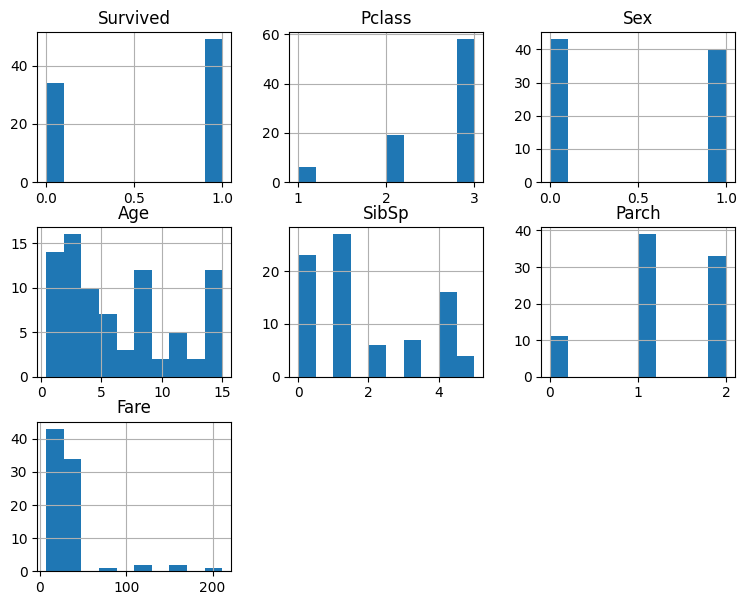

```python
children.hist(figsize=(9,7))
```

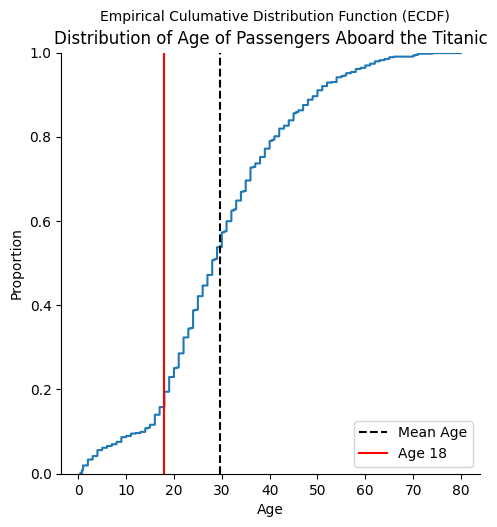

```python
age_list = df["Age"].dropna()
sns.displot(age_list, kind="ecdf")
plt.text(4.5, 1.075, "Empirical Culumative Distribution Function (ECDF)")
plt.title("Distribution of Age of Passengers Aboard the Titanic")
plt.axvline(x=age_list.mean(), color="black", linestyle="dashed", label="Mean Age")
plt.axvline(x=18, color="red", label="Age 18")
plt.legend()
plt.show()
```

```python
# Probability of children's survival
# Can also be seen in desciption table above Survived/mean
child_survival_probability = np.round(df[(df["Age"] < 16) &
	(df["Survived"] == 1)].shape[0] / children.shape[0], 4)
child_survival_probability
```

```
0.5904
```

#### Observation

```python
# Probability of women's survival
women = df[(df['Sex'] == 0) & (df['Age'] >= 16)]
surviving_women = df[(df['Sex'] == 0) & (df['Age'] >= 16) & (df['Survived'] == 1)]

women_survival_probability = np.round(surviving_women.shape[0] / women.shape[0], 4)
women_survival_probability
```

```
0.7752
```

```python
# Probability of men's survival
men = df[(df['Sex'] == 1) & (df['Age'] >= 16)]
surviving_men = df[(df['Sex'] == 1) & (df['Age'] >= 16) & (df['Survived'] == 1)]

men_survival_probability = np.round(surviving_men.shape[0] / men.shape[0], 4)
men_survival_probability
```

```
0.1743
```

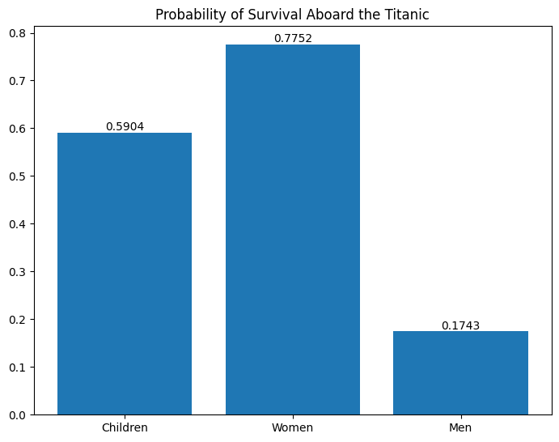

```python
fig = plt.figure()
ax = fig.add_axes([0,0,1,1])
x_axis = ["Children", "Women", "Men"]
data = [child_survival_probability, women_survival_probability, men_survival_probability]
ax.bar(x_axis, data)
for i in range(len(x_axis)):
	plt.text(i, data[i] + 0.005, data[i], ha="center")
plt.title("Probability of Survival Aboard the Titanic")
plt.show()
```

#### Observation

Women actually had the best chance of surviving and children had a pretty good chance, but men did not.

- Less than 1 in 5 men on the Titanic, ($< 20 \%$), survived
- Almost 4 out of 5 women, ($\approx 80 \%$), survived.

## Which feature is most informative to survival: class, being a child, or sex?

### Looking at Surviving Men

```python
surviving_men.describe()
```

|  | Survived | Pclass | Sex | Age | SibSp | Parch | Fare |
| --- | --- | --- | --- | --- | --- | --- | --- |
| count | 72.0 | 72.000000 | 72.0 | 72.000000 | 72.000000 | 72.000000 | 72.000000 |
| mean | 1.0 | 1.888889 | 1.0 | 34.069444 | 0.263889 | 0.125000 | 46.194621 |
| std | 0.0 | 0.957631 | 0.0 | 11.912032 | 0.474507 | 0.408966 | 84.836068 |
| min | 1.0 | 1.000000 | 1.0 | 16.000000 | 0.000000 | 0.000000 | 0.000000 |
| 25% | 1.0 | 1.000000 | 1.0 | 26.000000 | 0.000000 | 0.000000 | 8.050000 |
| 50% | 1.0 | 1.000000 | 1.0 | 32.000000 | 0.000000 | 0.000000 | 26.468750 |
| 75% | 1.0 | 3.000000 | 1.0 | 40.500000 | 0.250000 | 0.000000 | 53.685425 |
| max | 1.0 | 3.000000 | 1.0 | 80.000000 | 2.000000 | 2.000000 | 512.329200 |

```python
not_surviving_men = df[(df['Sex'] == 1) & (df['Age'] >= 16) & (df['Survived'] == 0)]
not_surviving_men.describe()
```

|  | Survived | Pclass | Sex | Age | SibSp | Parch | Fare |
| --- | --- | --- | --- | --- | --- | --- | --- |
| count | 341.0 | 341.000000 | 341.0 | 341.000000 | 341.000000 | 341.000000 | 341.000000 |
| mean | 0.0 | 2.395894 | 1.0 | 32.983871 | 0.266862 | 0.175953 | 22.438561 |
| std | 0.0 | 0.773750 | 0.0 | 13.115960 | 0.560240 | 0.582699 | 33.134832 |
| min | 0.0 | 1.000000 | 1.0 | 16.000000 | 0.000000 | 0.000000 | 0.000000 |
| 25% | 0.0 | 2.000000 | 1.0 | 23.000000 | 0.000000 | 0.000000 | 7.875000 |
| 50% | 0.0 | 3.000000 | 1.0 | 30.000000 | 0.000000 | 0.000000 | 10.500000 |
| 75% | 0.0 | 3.000000 | 1.0 | 40.000000 | 0.000000 | 0.000000 | 26.000000 |
| max | 0.0 | 3.000000 | 1.0 | 74.000000 | 4.000000 | 5.000000 | 263.000000 |

#### Observation

- Avg. Fare for survivors was about 2x more: 46.19 (survived) / 22.44 (not survived)
- Avg. Class for survivors was also higher: 1.89 (survived) / 2.40 (not survived)

Ratios increase even more when considering the medians over the averages.

```python
# Percent Chance of surviving for a 1st class vs. 3rd class man

first_class_men =  df[(df['Sex'] == 1) & (df['Age'] > 16) & (df['Pclass'] == 1)]
first_class_men_sr = np.round(first_class_men['Survived'].value_counts(normalize=True), 4)

display(first_class_men_sr)

third_class_men =  df[(df['Sex'] == 1) & (df['Age'] > 16) & (df['Pclass'] == 3)]
third_class_men_sr = np.round(third_class_men['Survived'].value_counts(normalize=True), 4)

display(third_class_men_sr)
```

```
0    0.6224
1    0.3776
Name: Survived, dtype: float64
```

```
0    0.8704
1    0.1296
Name: Survived, dtype: float64
```

#### Observation

An adult man in first class had a 3x better chance of surviving on the Titanic than an adult man in third class.

$$37.76\% :: 12.96\%$$

```
array([[<Axes: title={'center': 'Survived'}>,
        <Axes: title={'center': 'Pclass'}>,
        <Axes: title={'center': 'Sex'}>],
       [<Axes: title={'center': 'Age'}>,
        <Axes: title={'center': 'SibSp'}>,
        <Axes: title={'center': 'Parch'}>],
       [<Axes: title={'center': 'Fare'}>, <Axes: >, <Axes: >]],
      dtype=object)
```

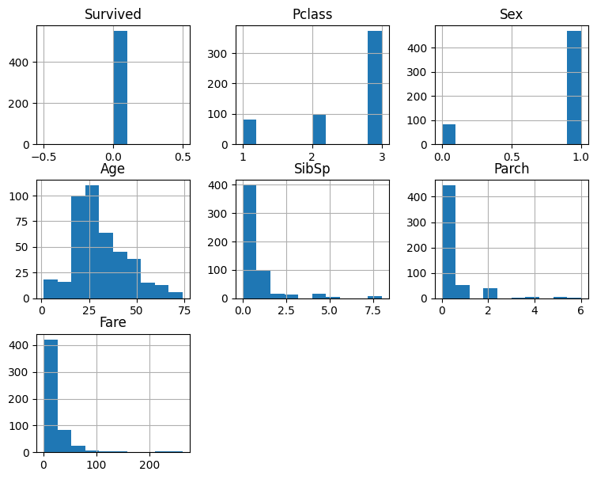

```python
not_survived = df[df["Survived"] == 0]
not_survived.hist(figsize=(9,7))
```

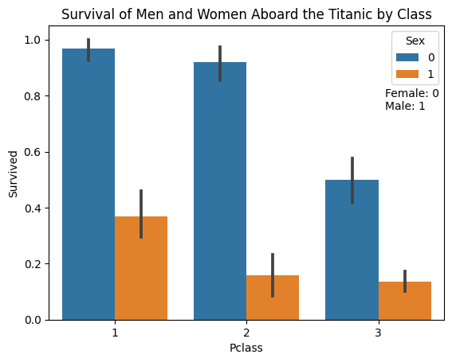

```python
sns.barplot(x='Pclass', y='Survived', hue="Sex", data=df)
plt.title("Survival of Men and Women Aboard the Titanic by Class")
plt.text(2.05, 0.75, "Female: 0\nMale: 1")
plt.show()
```

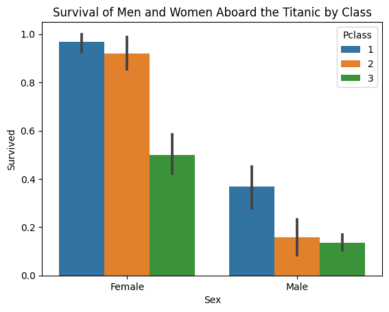

```python
sns.barplot(x='Sex', y='Survived', hue="Pclass", data=df)
plt.title("Survival of Men and Women Aboard the Titanic by Class")
plt.xticks([0, 1], labels=["Female", "Male"])
plt.show()
```

#### Observation

- Wealthy women had an almost 100% survival rate.
- 3rd class women had a 30 % higher survival rate than 1st class men.

Most Informative Feature: Sex